# R Notebook

eyan 23/01/2021

```r
library('tidyverse')
library('data.table')
url <- 'http://bit.ly/CarreFourDataset'
sup_market <- read.csv(url)
head(sup_market)
```

```
##    Invoice.ID Branch Customer.type Gender           Product.line Unit.price
## 1 750-67-8428      A        Member Female      Health and beauty      74.69
## 2 226-31-3081      C        Normal Female Electronic accessories      15.28
## 3 631-41-3108      A        Normal   Male     Home and lifestyle      46.33
## 4 123-19-1176      A        Member   Male      Health and beauty      58.22
## 5 373-73-7910      A        Normal   Male      Sports and travel      86.31
## 6 699-14-3026      C        Normal   Male Electronic accessories      85.39
##   Quantity     Tax      Date  Time     Payment   cogs gross.margin.percentage
## 1        7 26.1415  1/5/2019 13:08     Ewallet 522.83                4.761905
## 2        5  3.8200  3/8/2019 10:29        Cash  76.40                4.761905
## 3        7 16.2155  3/3/2019 13:23 Credit card 324.31                4.761905
## 4        8 23.2880 1/27/2019 20:33     Ewallet 465.76                4.761905
## 5        7 30.2085  2/8/2019 10:37     Ewallet 604.17                4.761905
## 6        7 29.8865 3/25/2019 18:30     Ewallet 597.73                4.761905
##   gross.income Rating    Total
## 1      26.1415    9.1 548.9715
## 2       3.8200    9.6  80.2200
## 3      16.2155    7.4 340.5255
## 4      23.2880    8.4 489.0480
## 5      30.2085    5.3 634.3785
## 6      29.8865    4.1 627.6165
```

```r
tail(sup_market)
```

```
##       Invoice.ID Branch Customer.type Gender           Product.line Unit.price
## 995  652-49-6720      C        Member Female Electronic accessories      60.95
## 996  233-67-5758      C        Normal   Male      Health and beauty      40.35
## 997  303-96-2227      B        Normal Female     Home and lifestyle      97.38
## 998  727-02-1313      A        Member   Male     Food and beverages      31.84
## 999  347-56-2442      A        Normal   Male     Home and lifestyle      65.82
## 1000 849-09-3807      A        Member Female    Fashion accessories      88.34
##      Quantity     Tax      Date  Time Payment   cogs gross.margin.percentage
## 995         1  3.0475 2/18/2019 11:40 Ewallet  60.95                4.761905
## 996         1  2.0175 1/29/2019 13:46 Ewallet  40.35                4.761905
## 997        10 48.6900  3/2/2019 17:16 Ewallet 973.80                4.761905
## 998         1  1.5920  2/9/2019 13:22    Cash  31.84                4.761905
## 999         1  3.2910 2/22/2019 15:33    Cash  65.82                4.761905
## 1000        7 30.9190 2/18/2019 13:28    Cash 618.38                4.761905
##      gross.income Rating     Total
## 995        3.0475    5.9   63.9975
## 996        2.0175    6.2   42.3675
## 997       48.6900    4.4 1022.4900
## 998        1.5920    7.7   33.4320
## 999        3.2910    4.1   69.1110
## 1000      30.9190    6.6  649.2990
```

```r
colSums(is.na(sup_market))
```

```
##              Invoice.ID                  Branch           Customer.type
##                       0                       0                       0
##                  Gender            Product.line              Unit.price
##                       0                       0                       0
##                Quantity                     Tax                    Date
##                       0                       0                       0
##                    Time                 Payment                    cogs
##                       0                       0                       0
## gross.margin.percentage            gross.income                  Rating
##                       0                       0                       0
##                   Total
##                       0
```

No null values were found

```r
dim(sup_market)
```

```
## [1] 1000   16
```

```r
sup_market[duplicated(sup_market)]
```

```
## data frame with 0 columns and 1000 rows
```

No duplicates

```r
summary(sup_market)
```

```
##   Invoice.ID           Branch          Customer.type         Gender
##  Length:1000        Length:1000        Length:1000        Length:1000
##  Class :character   Class :character   Class :character   Class :character
##  Mode  :character   Mode  :character   Mode  :character   Mode  :character
##
##
##
##  Product.line         Unit.price       Quantity          Tax
##  Length:1000        Min.   :10.08   Min.   : 1.00   Min.   : 0.5085
##  Class :character   1st Qu.:32.88   1st Qu.: 3.00   1st Qu.: 5.9249
##  Mode  :character   Median :55.23   Median : 5.00   Median :12.0880
##                     Mean   :55.67   Mean   : 5.51   Mean   :15.3794
##                     3rd Qu.:77.94   3rd Qu.: 8.00   3rd Qu.:22.4453
##                     Max.   :99.96   Max.   :10.00   Max.   :49.6500
##      Date               Time             Payment               cogs
##  Length:1000        Length:1000        Length:1000        Min.   : 10.17
##  Class :character   Class :character   Class :character   1st Qu.:118.50
##  Mode  :character   Mode  :character   Mode  :character   Median :241.76
##                                                           Mean   :307.59
##                                                           3rd Qu.:448.90
##                                                           Max.   :993.00
##  gross.margin.percentage  gross.income         Rating           Total
##  Min.   :4.762           Min.   : 0.5085   Min.   : 4.000   Min.   :  10.68
##  1st Qu.:4.762           1st Qu.: 5.9249   1st Qu.: 5.500   1st Qu.: 124.42
##  Median :4.762           Median :12.0880   Median : 7.000   Median : 253.85
##  Mean   :4.762           Mean   :15.3794   Mean   : 6.973   Mean   : 322.97
##  3rd Qu.:4.762           3rd Qu.:22.4453   3rd Qu.: 8.500   3rd Qu.: 471.35
##  Max.   :4.762           Max.   :49.6500   Max.   :10.000   Max.   :1042.65
```

# Reducing the number of features using PCA

```r
# importing the necessary library for PCA
library('FactoMineR')
library('ggbiplot')
label_encode <- function (column,dataframe){
  data <- dataframe[[column]]
  new_data <- as.integer(factor(data))
  # print(new_data)
  return (new_data)
}
supermarket.org <- sup_market[,-c(1,9,10)]
```

```r
# Label encoding columns
names_ <- c('Branch','Customer.type','Gender','Product.line','Payment')
for(nm in names_){
  supermarket.org[nm] <- label_encode(nm,supermarket.org)
}
supermarket <- supermarket.org
head(supermarket)
```

```
##   Branch Customer.type Gender Product.line Unit.price Quantity     Tax Payment
## 1      1             1      1            4      74.69        7 26.1415       3
## 2      3             2      1            1      15.28        5  3.8200       1
## 3      1             2      2            5      46.33        7 16.2155       2
## 4      1             1      2            4      58.22        8 23.2880       3
## 5      1             2      2            6      86.31        7 30.2085       3
## 6      3             2      2            1      85.39        7 29.8865       3
##     cogs gross.margin.percentage gross.income Rating    Total
## 1 522.83                4.761905      26.1415    9.1 548.9715
## 2  76.40                4.761905       3.8200    9.6  80.2200
## 3 324.31                4.761905      16.2155    7.4 340.5255
## 4 465.76                4.761905      23.2880    8.4 489.0480
## 5 604.17                4.761905      30.2085    5.3 634.3785
## 6 597.73                4.761905      29.8865    4.1 627.6165
```

```r
# Geting the principle components from the supermarkets dataset.
results <- prcomp(supermarket[,-c(10)], center = TRUE, scale. = TRUE)
summary(results)
```

```
## Importance of components:
##                           PC1     PC2    PC3    PC4     PC5     PC6     PC7
## Standard deviation     2.2201 1.06317 1.0317 1.0099 0.99289 0.97714 0.96273
## Proportion of Variance 0.4107 0.09419 0.0887 0.0850 0.08215 0.07957 0.07724
## Cumulative Proportion  0.4107 0.50493 0.5936 0.6786 0.76078 0.84035 0.91758
##                            PC8     PC9      PC10      PC11      PC12
## Standard deviation     0.94823 0.29977 2.112e-16 1.456e-16 1.214e-16
## Proportion of Variance 0.07493 0.00749 0.000e+00 0.000e+00 0.000e+00
## Cumulative Proportion  0.99251 1.00000 1.000e+00 1.000e+00 1.000e+00
```

The first principal component has the largest proportion explaining 41% of the variance in the data. The first 9 components explain the all variance in the data, making the last 3 obsolete

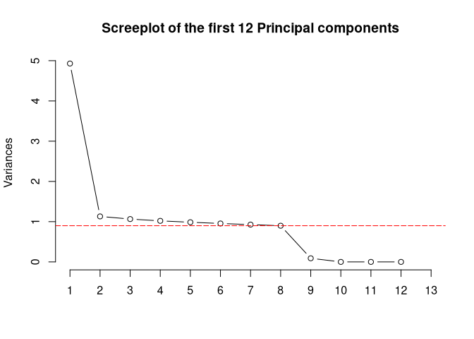

```r
screeplot(results, type = "l", npcs = 13, main = "Screeplot of the first 12 Principal components")
abline(h = 0.9, col="red", lty=5)
```

The first 9 principal components explain the most in the data, explainig 99% of the variance. These are the most important features in the dataset.

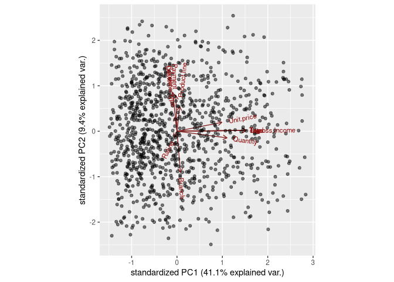

```r
ggbiplot(results,labels.size = 5, alpha = 0.5)
```

Unit price,gross income,tax and quantity contribute to PC1 Payment,gender,Product line and customer type contribute to PC2

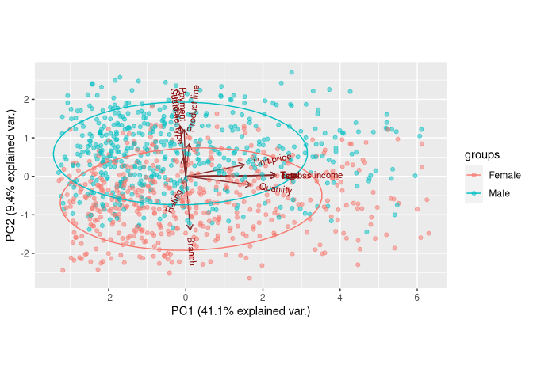

```r
clusters <- function (name,pc1=1,pc2=2){
  cl_list <- factor(sup_market[[name]])
  # species <- cl_list$species
  ggbiplot(results,,choices=c(pc1,pc2),ellipse = TRUE,groups = cl_list, obs.scale = 1, var.scale = 1,labels.size = 5, alpha = 0.5)
}
clusters('Gender')
```

The clusters of the gender show: Males are clustered at the top characterised by all features but the branch, while females are clustered at the bottom with unitprice,tax,gross income,rating and branch influencing their buying.

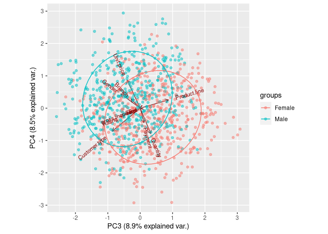

```r
clusters('Gender',3,4)
```

Since the 3rd and 4th princpal components explain lower variances than the first two, i doesnt do that good a job at showing the pattern shown in the previous plot. although it does give a hint on where the different genders lie.

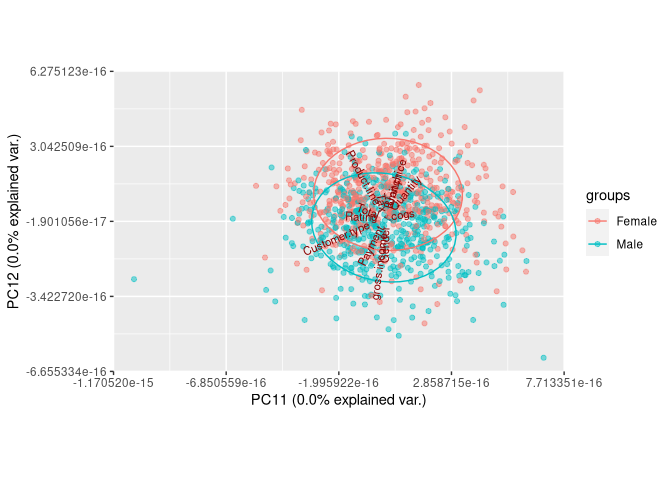

```r
clusters('Gender',11,12)
```

The last 2 principle components perform even worse since they ecplain so little of the variance in the dataset.

# Reducing the attributes using Feature Selection

## Method 1 filter method: high correlation filter

```r
library('caret')
```

```r
library('corrplot')
supermarket_ <- supermarket.org[,-c(10)]
corr_ <- cor(supermarket_)
corr_
```

```
##                    Branch Customer.type       Gender Product.line   Unit.price
## Branch         1.00000000   -0.01960787 -0.056317558 -0.053937557  0.028202440
## Customer.type -0.01960787    1.00000000  0.039996160 -0.036800311 -0.020237875
## Gender        -0.05631756    0.03999616  1.000000000  0.005193197  0.015444630
## Product.line  -0.05393756   -0.03680031  0.005193197  1.000000000  0.019321028
## Unit.price     0.02820244   -0.02023787  0.015444630  0.019321028  1.000000000
## Quantity       0.01596379   -0.01676271 -0.074258307  0.020256001  0.010777564
## Tax            0.04104666   -0.01967028 -0.049450989  0.031620725  0.633962089
## Payment       -0.05010429    0.01807344  0.044577609  0.029896383 -0.015941048
## cogs           0.04104666   -0.01967028 -0.049450989  0.031620725  0.633962089
## gross.income   0.04104666   -0.01967028 -0.049450989  0.031620725  0.633962089
## Rating         0.01023848    0.01888867  0.004800208 -0.020528973 -0.008777507
## Total          0.04104666   -0.01967028 -0.049450989  0.031620725  0.633962089
##                  Quantity         Tax      Payment        cogs gross.income
## Branch         0.01596379  0.04104666 -0.050104288  0.04104666   0.04104666
## Customer.type -0.01676271 -0.01967028  0.018073436 -0.01967028  -0.01967028
## Gender        -0.07425831 -0.04945099  0.044577609 -0.04945099  -0.04945099
## Product.line   0.02025600  0.03162072  0.029896383  0.03162072   0.03162072
## Unit.price     0.01077756  0.63396209 -0.015941048  0.63396209   0.63396209
## Quantity       1.00000000  0.70551019 -0.003920990  0.70551019   0.70551019
## Tax            0.70551019  1.00000000 -0.012433637  1.00000000   1.00000000
## Payment       -0.00392099 -0.01243364  1.000000000 -0.01243364  -0.01243364
## cogs           0.70551019  1.00000000 -0.012433637  1.00000000   1.00000000
## gross.income   0.70551019  1.00000000 -0.012433637  1.00000000   1.00000000
## Rating        -0.01581490 -0.03644170 -0.005381289 -0.03644170  -0.03644170
## Total          0.70551019  1.00000000 -0.012433637  1.00000000   1.00000000
##                     Rating       Total
## Branch         0.010238476  0.04104666
## Customer.type  0.018888672 -0.01967028
## Gender         0.004800208 -0.04945099
## Product.line  -0.020528973  0.03162072
## Unit.price    -0.008777507  0.63396209
## Quantity      -0.015814905  0.70551019
## Tax           -0.036441705  1.00000000
## Payment       -0.005381289 -0.01243364
## cogs          -0.036441705  1.00000000
## gross.income  -0.036441705  1.00000000
## Rating         1.000000000 -0.03644170
## Total         -0.036441705  1.00000000
```

High correlations from tax,gross income ,cogs and total

```r
high_cor <- findCorrelation(corr_, cutoff=0.75)
high_cor
```

```
## [1]  9 12  7
```

```r
# Removing the highly correlated features in index (9,12,7)
final <- supermarket_[-high_cor]
```

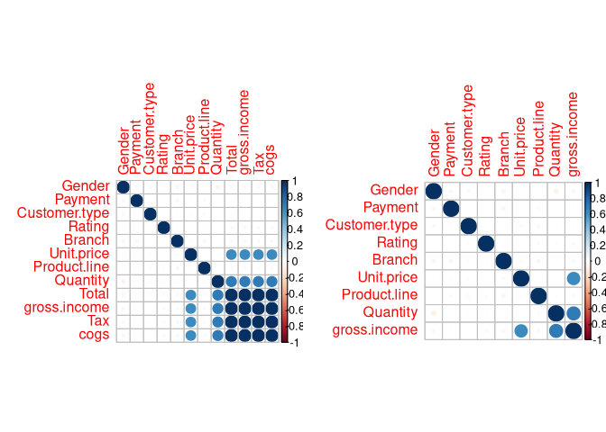

```r
# Plotting the correlations for comparison
par(mfrow = c(1,2))
corrplot(corr_, order = "hclust")
corrplot(cor(final), order = "hclust")
```

Feature selection removes the most correlated features from the dataset in this case were left with 9 features that are not overly correlated

## Method 2 : Wrapper Methods

```r
library('clustvarsel')
library('mclust')
```

```r
# Sequential forward greedy search using the default number of groups
out <- clustvarsel(supermarket_)
out
```

```
## ------------------------------------------------------
## Variable selection for Gaussian model-based clustering
## Stepwise (forward/backward) greedy search
## ------------------------------------------------------
##
##  Variable proposed Type of step   BICclust Model G   BICdiff Decision
##           Quantity          Add  -4308.761     E 9  687.4466 Accepted
##               cogs          Add -16306.851   VEV 9 1083.0132 Accepted
##         Unit.price          Add -21393.079   EVV 7 2812.3733 Accepted
##         Unit.price       Remove -16306.851   VEV 9 2812.3733 Rejected
##             Rating          Add -25510.859   EVV 7 -184.0917 Rejected
##         Unit.price       Remove -16306.851   VEV 9 2812.3733 Rejected
##
## Selected subset: Quantity, cogs, Unit.price
```

```r
final2 <- supermarket_[,out$subset]
head(final2)
```

```
##   Quantity   cogs Unit.price
## 1        7 522.83      74.69
## 2        5  76.40      15.28
## 3        7 324.31      46.33
## 4        8 465.76      58.22
## 5        7 604.17      86.31
## 6        7 597.73      85.39
```

```r
mod <- Mclust(final2)
summary(mod)
```

```
## ----------------------------------------------------
## Gaussian finite mixture model fitted by EM algorithm
## ----------------------------------------------------
##
## Mclust EVV (ellipsoidal, equal volume) model with 7 components:
##
##  log-likelihood    n df       BIC       ICL
##       -10478.95 1000 63 -21393.08 -21446.89
##
## Clustering table:
##   1   2   3   4   5   6   7
## 173 134 126 148 128 142 149
```

There were achieved 7 clusters in the selected subset of data

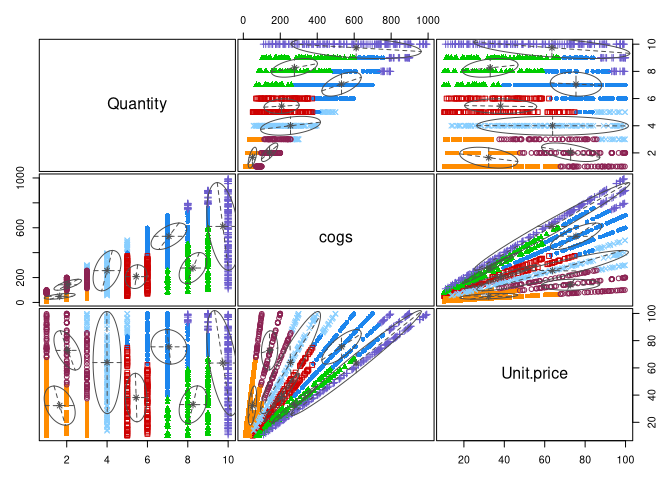

```r
plot(mod,c("classification"))
```

The unsupervised clustering shows 7 clusters from the 3 attributes selected